# Assignment 6 Analysis of Longitudinal Data

#### Plotting the standardized data

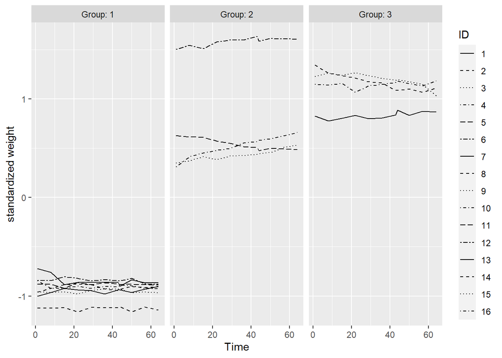

```r
ggplot(RATSLS, aes(x = Time, y = stdweight, linetype = ID)) +
  geom_line() +
  scale_linetype_manual(values = rep(1:16, times=6)) +
  facet_grid(. ~ Group, labeller = label_both) +
  scale_y_continuous(name = "standardized weight")
```

#### Summarize the Rat Weights by mean and standard error

```r
RATSLSsum <- RATSLS %>%
  group_by(Group, Time) %>%
  summarise(mean = mean(Weight), n = n(), se = sd(Weight)/sqrt(n)) %>%
  ungroup()
```

#### Ploting the summarized data

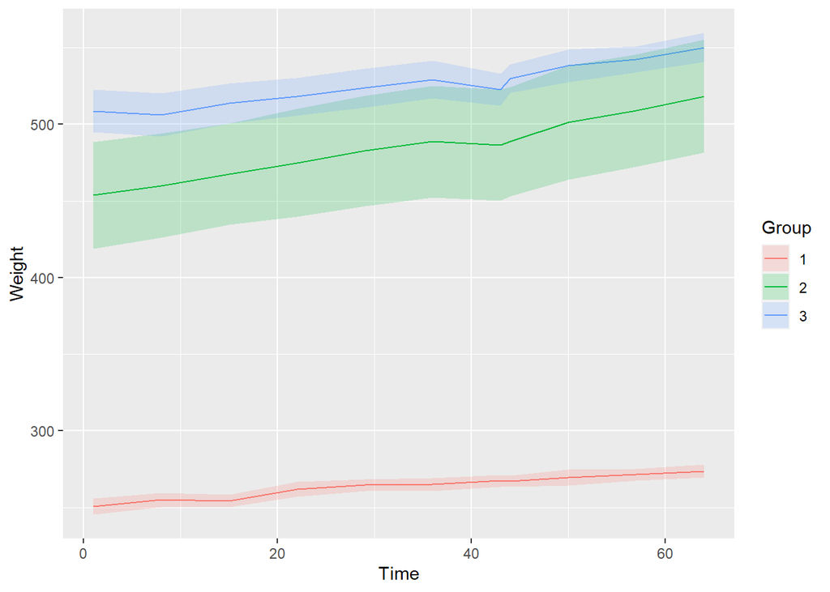

```r
ggplot(RATSLSsum, aes(x = Time, y = mean)) +
  geom_line(aes(color = Group)) +
  geom_ribbon(aes(ymin = mean - se, ymax = mean + se, fill = Group), alpha = 0.2) +
  scale_y_continuous(name = "Weight")
```

#### Outlier Hunting

```r
# Create a summary data by diet group and rat ID with mean as the summary variable (ignoring baseline Time = 1)
RATSL8S <- RATSL %>%
  filter(Time > 1) %>%
  group_by(Group, ID) %>%
  summarise(mean=mean(Weight) ) %>%
  ungroup()
```

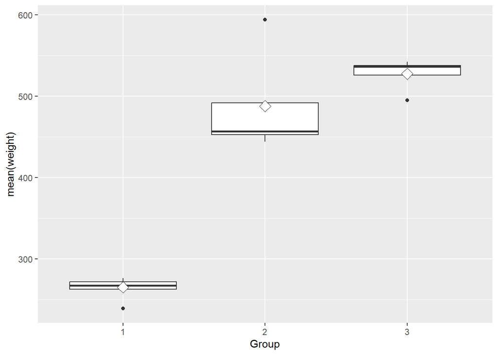

```r
# Draw a boxplot of the mean versus treatment
ggplot(RATSL8S, aes(x = Group, y = mean)) +
  geom_boxplot() +
  stat_summary(fun = "mean", geom = "point", shape=23, size=4, fill = "white") +
  scale_y_continuous(name = "mean(weight)")
```

```r
head(RATSL8S, n=16)
```

```
## # A tibble: 16 × 3
##    Group ID     mean
##    <fct> <fct> <dbl>
##  1 1     1      263.
##  2 1     2      239.
##  3 1     3      262.
##  4 1     4      267.
##  5 1     5      271.
##  6 1     6      276.
##  7 1     7      275.
##  8 1     8      268.
##  9 2     9      444.
## 10 2     10     458.
## 11 2     11     456.
## 12 2     12     594
## 13 3     13     495.
## 14 3     14     536.
## 15 3     15     542.
## 16 3     16     536.
```

##### from here I can see that we have one outlier above 500 and one below 250 and one from group 3 that is 495.2

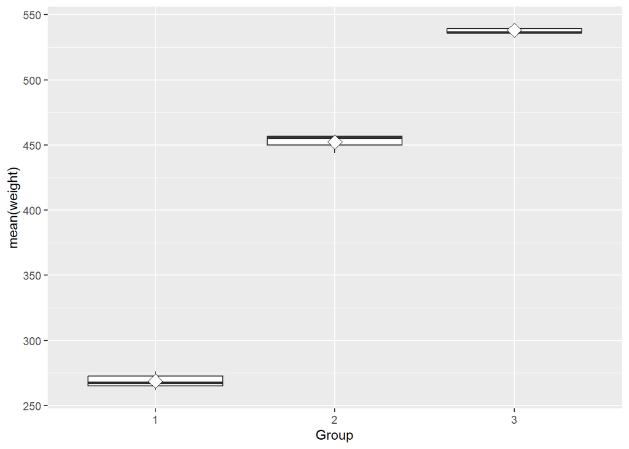

```r
#removing outliers
RATSL8S1 <- RATSL8S %>%
  filter(mean<550 & mean>250 & mean!=495.2)

ggplot(RATSL8S1, aes(x = Group, y = mean)) +
  geom_boxplot() +
  stat_summary(fun = "mean", geom = "point", shape=23, size=4, fill = "white") +
  scale_y_continuous(name = "mean(weight)")
```

### T tests

#### exclude group 1

```r
t.test(mean ~ Group, data = filter(RATSL8S1,Group!=1), var.equal = TRUE)
```

```
##
##  Two Sample t-test
##
## data:  mean by Group
## t = -18.235, df = 4, p-value = 5.32e-05
## alternative hypothesis: true difference in means between group 2 and group 3 is not equal to 0
## 95 percent confidence interval:
##  -98.94088 -72.79246
## sample estimates:
## mean in group 2 mean in group 3
##        452.4000        538.2667
```

#### exclude group 2

```r
t.test(mean ~ Group, data = filter(RATSL8S1,Group!=2), var.equal = TRUE)
```

```
##
##  Two Sample t-test
##
## data:  mean by Group
## t = -77.715, df = 8, p-value = 8.377e-13
## alternative hypothesis: true difference in means between group 1 and group 3 is not equal to 0
## 95 percent confidence interval:
##  -277.5065 -261.5125
## sample estimates:
## mean in group 1 mean in group 3
##        268.7571        538.2667
```

#### exclude group 3

```r
t.test(mean ~ Group, data = filter(RATSL8S1,Group!=3), var.equal = TRUE)
```

```
##
##  Two Sample t-test
##
## data:  mean by Group
## t = -44.305, df = 8, p-value = 7.434e-11
## alternative hypothesis: true difference in means between group 1 and group 2 is not equal to 0
## 95 percent confidence interval:
##  -193.2012 -174.0845
## sample estimates:
## mean in group 1 mean in group 2
##        268.7571        452.4000
```

##### all the T test comparisons reject the null hypothesis, the difference between each pair of groups is not zero. There is a statistically significant difference between each group.

### Analysis of Varianace ANOVA

#### Create a baseline

```r
RATSL8S2 <- RATSL8S %>%
  mutate(baseline = RATS$WD1)
```

#### Filter out the outliers like before

```r
RATSL8S2 <- RATSL8S2 %>%
  filter(mean<550 & mean>250 & mean!=495.2)
```

#### Fit a model and perform ANOVA

```r
fit <- lm(mean ~ baseline + Group, data = RATSL8S2)

anova(fit)
```

```
## Analysis of Variance Table
##
## Response: mean
##           Df Sum Sq Mean Sq  F value    Pr(>F)
## baseline   1 174926  174926 6630.941 3.216e-14 ***
## Group      2   2065    1033   39.147 3.628e-05 ***
## Residuals  9    237      26
## ---
## Signif. codes:  0 '***' 0.001 '**' 0.01 '*' 0.05 '.' 0.1 ' ' 1
```

##### Conclusion: Both baseline weight and group had an effect on weight. The heavier the rat was at the beginning, the more likely it was to be heavier at the end, which makes sense, if you get more calorie dense food at a higher weight it will go up and be even higher. The group also effected the weight increase.

## Part 2: BPRS data

#### Load the data

```r
BPRS <- read.table("https://raw.githubusercontent.com/KimmoVehkalahti/MABS/master/Examples/data/BPRS.txt", sep =" ", header = T)

BPRS$treatment <- factor(BPRS$treatment)
BPRS$subject <- factor(BPRS$subject)

BPRSL <-  pivot_longer(BPRS, cols = -c(treatment, subject),
                       names_to = "weeks", values_to = "bprs") %>%
  arrange(weeks)

BPRSL <-  BPRSL %>%
  mutate(week = as.integer(substr(weeks,5,5)))

str(BPRSL)
```

```
## tibble [360 × 5] (S3: tbl_df/tbl/data.frame)
##  $ treatment: Factor w/ 2 levels "1","2": 1 1 1 1 1 1 1 1 1 1 ...
##  $ subject  : Factor w/ 20 levels "1","2","3","4",..: 1 2 3 4 5 6 7 8 9 10 ...
##  $ weeks    : chr [1:360] "week0" "week0" "week0" "week0" ...
##  $ bprs     : int [1:360] 42 58 54 55 72 48 71 30 41 57 ...
##  $ week     : int [1:360] 0 0 0 0 0 0 0 0 0 0 ...
```

##### Good now I have my data in long form with factorized variables

#### Plot first ask questions later

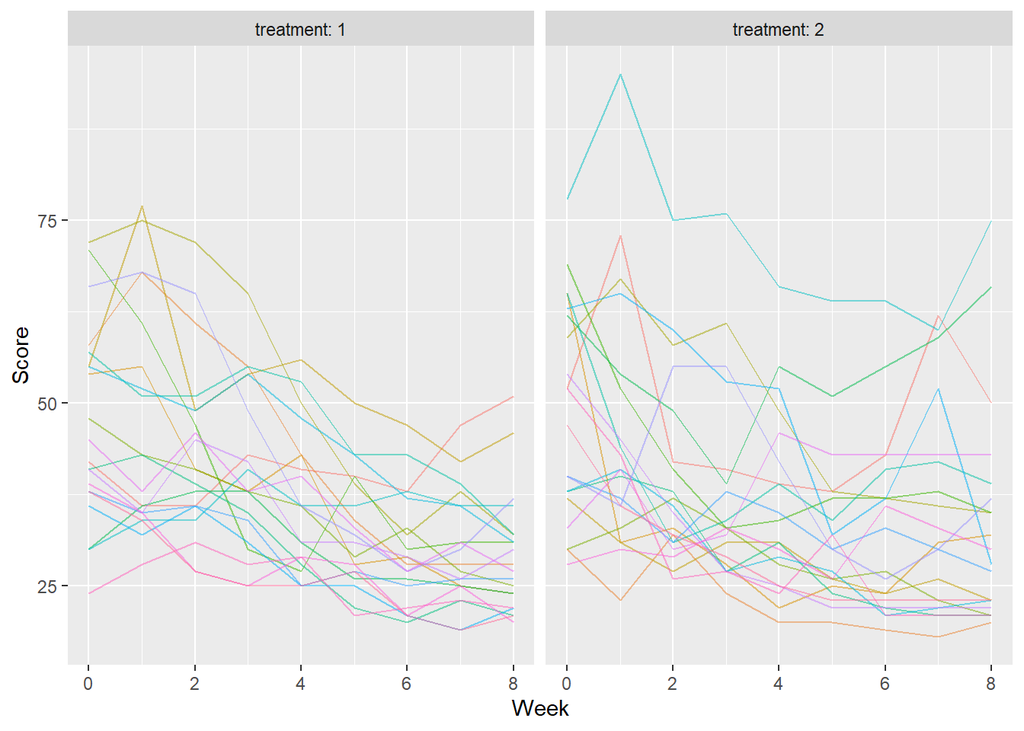

```r
ggplot(BPRSL, aes(x = week, y = bprs, group = subject)) +
  geom_line(aes(col = subject), alpha = 0.5) +
  facet_grid(. ~ treatment, labeller = label_both) +
  scale_x_continuous(name = "Week") +
  scale_y_continuous(name = "Score") +
  theme(legend.position = "none")
```

##### I can’t really see a pattern or correlation here so far.

### Regression Modelling

#### Linear Model

```r
BPRS_lm <- lm(bprs ~ week + treatment, data = BPRSL)
summary(BPRS_lm)
```

```
##
## Call:
## lm(formula = bprs ~ week + treatment, data = BPRSL)
##
## Residuals:
##     Min      1Q  Median      3Q     Max
## -22.454  -8.965  -3.196   7.002  50.244
##
## Coefficients:
##             Estimate Std. Error t value Pr(>|t|)
## (Intercept)  46.4539     1.3670  33.982   <2e-16 ***
## week         -2.2704     0.2524  -8.995   <2e-16 ***
## treatment2    0.5722     1.3034   0.439    0.661
## ---
## Signif. codes:  0 '***' 0.001 '**' 0.01 '*' 0.05 '.' 0.1 ' ' 1
##
## Residual standard error: 12.37 on 357 degrees of freedom
## Multiple R-squared:  0.1851, Adjusted R-squared:  0.1806
## F-statistic: 40.55 on 2 and 357 DF,  p-value: < 2.2e-16
```

##### Here it seems that week has a higher correlation that treatment in terms of bprs scores, they seem to decline by 2 points a week.

#### Random Intercept Model

```r
BPRS_ref <- lmer(bprs ~ week + treatment + (1 | subject), data = BPRSL, REML = FALSE)

summary(BPRS_ref)
```

```
## Linear mixed model fit by maximum likelihood  ['lmerMod']
## Formula: bprs ~ week + treatment + (1 | subject)
##    Data: BPRSL
##
##      AIC      BIC   logLik deviance df.resid
##   2748.7   2768.1  -1369.4   2738.7      355
##
## Scaled residuals:
##     Min      1Q  Median      3Q     Max
## -3.0481 -0.6749 -0.1361  0.4813  3.4855
##
## Random effects:
##  Groups   Name        Variance Std.Dev.
##  subject  (Intercept)  47.41    6.885
##  Residual             104.21   10.208
## Number of obs: 360, groups:  subject, 20
##
## Fixed effects:
##             Estimate Std. Error t value
## (Intercept)  46.4539     1.9090  24.334
## week         -2.2704     0.2084 -10.896
## treatment2    0.5722     1.0761   0.532
##
## Correlation of Fixed Effects:
##            (Intr) week
## week       -0.437
## treatment2 -0.282  0.000
```

#### Random slope and random intercept model

```r
BPRS_ref2 <- lmer(bprs ~ week + treatment + (week | subject), data = BPRSL, REML = FALSE)

summary(BPRS_ref2)
```

```
## Linear mixed model fit by maximum likelihood  ['lmerMod']
## Formula: bprs ~ week + treatment + (week | subject)
##    Data: BPRSL
##
##      AIC      BIC   logLik deviance df.resid
##   2745.4   2772.6  -1365.7   2731.4      353
##
## Scaled residuals:
##     Min      1Q  Median      3Q     Max
## -2.8919 -0.6194 -0.0691  0.5531  3.7976
##
## Random effects:
##  Groups   Name        Variance Std.Dev. Corr
##  subject  (Intercept) 64.8222  8.0512
##           week         0.9609  0.9802   -0.51
##  Residual             97.4305  9.8707
## Number of obs: 360, groups:  subject, 20
##
## Fixed effects:
##             Estimate Std. Error t value
## (Intercept)  46.4539     2.1052  22.066
## week         -2.2704     0.2977  -7.626
## treatment2    0.5722     1.0405   0.550
##
## Correlation of Fixed Effects:
##            (Intr) week
## week       -0.582
## treatment2 -0.247  0.000
```

#### ANOVA of the two models

```r
anova(BPRS_ref2, BPRS_ref)
```

```
## Data: BPRSL
## Models:
## BPRS_ref: bprs ~ week + treatment + (1 | subject)
## BPRS_ref2: bprs ~ week + treatment + (week | subject)
##           npar    AIC    BIC  logLik deviance  Chisq Df Pr(>Chisq)
## BPRS_ref     5 2748.7 2768.1 -1369.4   2738.7
## BPRS_ref2    7 2745.4 2772.6 -1365.7   2731.4 7.2721  2    0.02636 *
## ---
## Signif. codes:  0 '***' 0.001 '**' 0.01 '*' 0.05 '.' 0.1 ' ' 1
```

##### Comparing between the two models we see that the second performs better

#### Adding Interaction

```r
BPRS_ref3 <- lmer(bprs ~ week * treatment + (week | subject), data = BPRSL, REML = FALSE)

summary(BPRS_ref3)
```

```
## Linear mixed model fit by maximum likelihood  ['lmerMod']
## Formula: bprs ~ week * treatment + (week | subject)
##    Data: BPRSL
##
##      AIC      BIC   logLik deviance df.resid
##   2744.3   2775.4  -1364.1   2728.3      352
##
## Scaled residuals:
##     Min      1Q  Median      3Q     Max
## -3.0512 -0.6271 -0.0768  0.5288  3.9260
##
## Random effects:
##  Groups   Name        Variance Std.Dev. Corr
##  subject  (Intercept) 64.9964  8.0620
##           week         0.9687  0.9842   -0.51
##  Residual             96.4707  9.8220
## Number of obs: 360, groups:  subject, 20
##
## Fixed effects:
##                 Estimate Std. Error t value
## (Intercept)      47.8856     2.2521  21.262
## week             -2.6283     0.3589  -7.323
## treatment2       -2.2911     1.9090  -1.200
## week:treatment2   0.7158     0.4010   1.785
##
## Correlation of Fixed Effects:
##             (Intr) week   trtmn2
## week        -0.650
## treatment2  -0.424  0.469
## wek:trtmnt2  0.356 -0.559 -0.840
```

#### Anova of RSRI and RSRI+i

```r
anova(BPRS_ref3, BPRS_ref2)
```

```
## Data: BPRSL
## Models:
## BPRS_ref2: bprs ~ week + treatment + (week | subject)
## BPRS_ref3: bprs ~ week * treatment + (week | subject)
##           npar    AIC    BIC  logLik deviance  Chisq Df Pr(>Chisq)
## BPRS_ref2    7 2745.4 2772.6 -1365.7   2731.4
## BPRS_ref3    8 2744.3 2775.4 -1364.1   2728.3 3.1712  1    0.07495 .
## ---
## Signif. codes:  0 '***' 0.001 '**' 0.01 '*' 0.05 '.' 0.1 ' ' 1
```

#### Plotting Fitted Scores

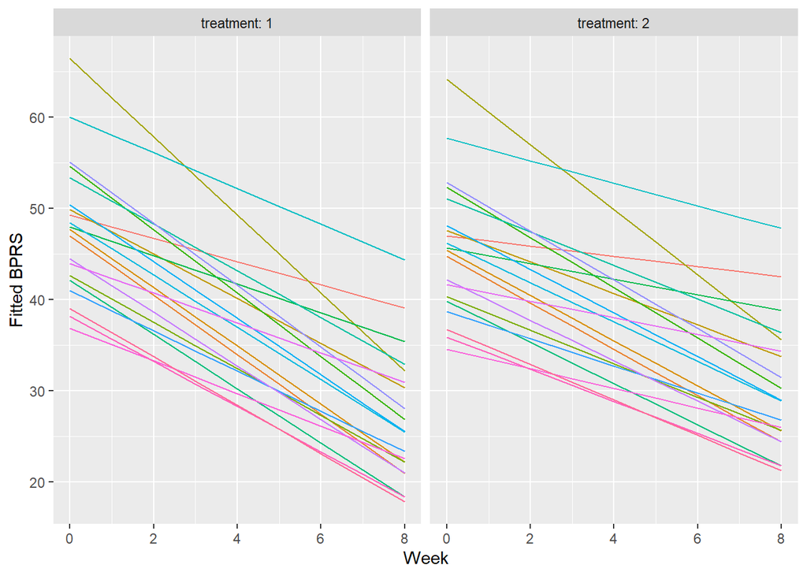

```r
Fitted <- fitted(BPRS_ref3)
BPRSL$Fitted <- Fitted

ggplot(BPRSL, aes(x = week, y = Fitted, group = subject)) +
  geom_line(aes(col = subject)) +
  facet_grid(. ~ treatment, labeller = label_both) +
  scale_x_continuous(name = "Week") +
  scale_y_continuous(name = "Fitted BPRS") +
  theme(legend.position = "none")
```

#### Observed vs Fitted

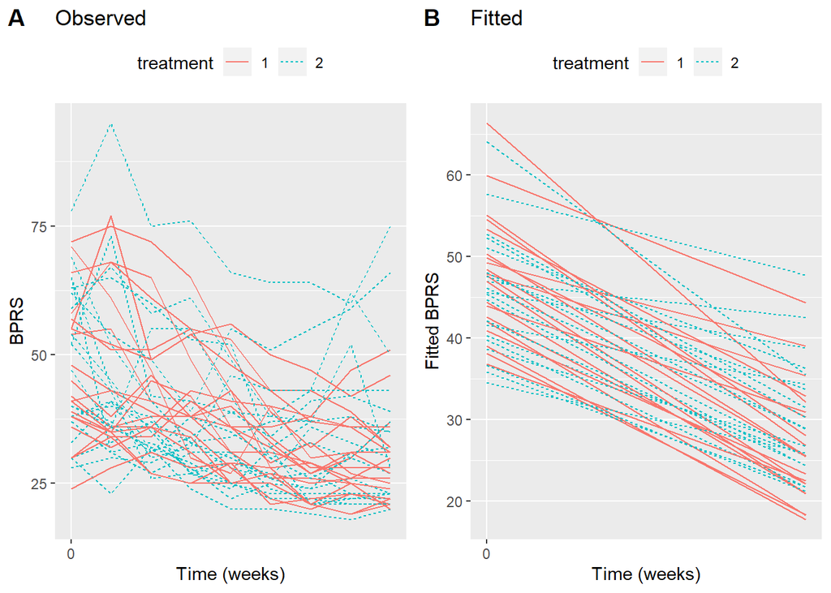

```r
Fitted_plot<- ggplot(BPRSL, aes(x = week, y = Fitted, group = interaction(treatment, subject))) +
  geom_line(aes(linetype = treatment, colour=treatment)) +
  scale_x_continuous(name = "Time (weeks)", breaks = seq(0, 60, 20)) +
  scale_y_continuous(name = "Fitted BPRS") +
  theme(legend.position = "top")  +
  ggtitle("Fitted")

# Plot the RATSL data
Observed_plot <- ggplot(BPRSL, aes(x = week, y = bprs, group = interaction(treatment, subject)))+
  geom_line(aes(linetype = treatment, colour=treatment))+
  scale_x_continuous(name = "Time (weeks)", breaks = seq(0, 60, 20))+
  scale_y_continuous(name = "BPRS")+
  theme(legend.position = "top")+
  ggtitle("Observed")

plot_grid(Observed_plot, Fitted_plot, labels = "AUTO")
```

#### Making sense out of madness, the general trend is for the BPRS scores to go down, regardless of treatment, which was difficult to see from the oberserved data.

##Complete, Happy Holidays:)